# Project_Final_Nhom11

## Project Final:

## The Movie Recommender System

Team 11:

- Lý Quốc Dũng : 19133015
- Đoàn Trần Đăng Khoa: 19133028
- Lê Thị Kim Ngân : 19133038
- Bùi Thị Ngân Tuyền : 19133066

### Task assignment

Lý Quốc Dũng : 19133015

- EDA + Content-Based

Đoàn Trần Đăng Khoa: 19133028

- EDA + Clean Data + Demographic Filtering

Lê Thị Kim Ngân : 19133038

- EDA + Collaborative Filtering

Bùi Thị Ngân Tuyền : 19133066

- EDA + Apriori Algorithiom

### Introduction

Hệ thống đề xuất dự đoán khả năng người dùng sẽ ủng hộ một mặt hàng. Dựa trên tìm kiếm của người dùng và tương tác trước đây của người dùng với nguồn dữ liệu mà hệ thống học hỏi (ngoài dữ liệu từ những người dùng khác hoặc xu hướng lịch sử), hệ thống có khả năng đề xuất một mặt hàng cho người dùng. Ví dụ Netflix giới thiệu những bộ phim mà họ nghĩ rằng chúng tôi sẽ thích

### Mô tả data

- Data được lấy từ nguồn Kaggle : https://www.kaggle.com/datasets/tmdb/tmdb-movie-metadata?select=tmdb_5000_credits.csv
- Data gồm có 4 csv : ratings.csv, movies.csv, tmdb_5000_credits.csv, tmdb_5000_movies.csv
  - ratings.csv: 100837 dòng ,4 cột :userId,movieId,rating,timestamp
  - movies.csv: 9743 dòng, 3 cột :movieId,title,genres
  - tmdb_5000_credits.csv : 4814 dòng, 4 cột: movie_id,title,cast,crew
  - tmdb_5000_movies.csv: 4804 dòng, 20 cột: budget,genres,homepage,id,keywords,original_language,original_title,overview, popularity,production_companies,production_countries,release_date,revenue,runtime,spoken_languages,status,tagline,title,vote_average,vote_count

### Motivation

- Để làm sạch dữ liệu cho hiệu suất tốt hơn của mô hình và EDA.
- Để thực hiện EDA để có được cái nhìn sâu sắc
- Để xây dựng hệ thống đề xuất phim đề xuất phim dựa trên sự tương đồng và hành vi xem
- Để khám phá kiến thức và kỹ năng

### Clean Data

```python
import pandas as pd
import numpy as np
import ast
```

```python
movie= pd.read_csv("tmdb_5000_movies.csv")
movie.head()
```

|  | budget | genres | homepage | id | keywords | original_language | original_title | overview | popularity | production_companies | production_countries | release_date | revenue | runtime | spoken_languages | status | tagline | title | vote_average | vote_count |
| --- | --- | --- | --- | --- | --- | --- | --- | --- | --- | --- | --- | --- | --- | --- | --- | --- | --- | --- | --- | --- |
| 0 | 237000000 | [{"id": 28, "name": "Action"}, {"id": 12, "nam... | http://www.avatarmovie.com/ | 19995 | [{"id": 1463, "name": "culture clash"}, {"id":... | en | Avatar | In the 22nd century, a paraplegic Marine is di... | 150.437577 | [{"name": "Ingenious Film Partners", "id": 289... | [{"iso_3166_1": "US", "name": "United States o... | 2009-12-10 | 2787965087 | 162.0 | [{"iso_639_1": "en", "name": "English"}, {"iso... | Released | Enter the World of Pandora. | Avatar | 7.2 | 11800 |
| 1 | 300000000 | [{"id": 12, "name": "Adventure"}, {"id": 14, "... | http://disney.go.com/disneypictures/pirates/ | 285 | [{"id": 270, "name": "ocean"}, {"id": 726, "na... | en | Pirates of the Caribbean: At World's End | Captain Barbossa, long believed to be dead, ha... | 139.082615 | [{"name": "Walt Disney Pictures", "id": 2}, {"... | [{"iso_3166_1": "US", "name": "United States o... | 2007-05-19 | 961000000 | 169.0 | [{"iso_639_1": "en", "name": "English"}] | Released | At the end of the world, the adventure begins. | Pirates of the Caribbean: At World's End | 6.9 | 4500 |
| 2 | 245000000 | [{"id": 28, "name": "Action"}, {"id": 12, "nam... | http://www.sonypictures.com/movies/spectre/ | 206647 | [{"id": 470, "name": "spy"}, {"id": 818, "name... | en | Spectre | A cryptic message from Bond’s past sends him o... | 107.376788 | [{"name": "Columbia Pictures", "id": 5}, {"nam... | [{"iso_3166_1": "GB", "name": "United Kingdom"... | 2015-10-26 | 880674609 | 148.0 | [{"iso_639_1": "fr", "name": "Fran\u00e7ais"},... | Released | A Plan No One Escapes | Spectre | 6.3 | 4466 |
| 3 | 250000000 | [{"id": 28, "name": "Action"}, {"id": 80, "nam... | http://www.thedarkknightrises.com/ | 49026 | [{"id": 849, "name": "dc comics"}, {"id": 853,... | en | The Dark Knight Rises | Following the death of District Attorney Harve... | 112.312950 | [{"name": "Legendary Pictures", "id": 923}, {"... | [{"iso_3166_1": "US", "name": "United States o... | 2012-07-16 | 1084939099 | 165.0 | [{"iso_639_1": "en", "name": "English"}] | Released | The Legend Ends | The Dark Knight Rises | 7.6 | 9106 |
| 4 | 260000000 | [{"id": 28, "name": "Action"}, {"id": 12, "nam... | http://movies.disney.com/john-carter | 49529 | [{"id": 818, "name": "based on novel"}, {"id":... | en | John Carter | John Carter is a war-weary, former military ca... | 43.926995 | [{"name": "Walt Disney Pictures", "id": 2}] | [{"iso_3166_1": "US", "name": "United States o... | 2012-03-07 | 284139100 | 132.0 | [{"iso_639_1": "en", "name": "English"}] | Released | Lost in our world, found in another. | John Carter | 6.1 | 2124 |

```python
credits= pd.read_csv("tmdb_5000_credits.csv")
credits.head()
```

|  | movie_id | title | cast | crew |
| --- | --- | --- | --- | --- |
| 0 | 19995 | Avatar | [{"cast_id": 242, "character": "Jake Sully", "... | [{"credit_id": "52fe48009251416c750aca23", "de... |
| 1 | 285 | Pirates of the Caribbean: At World's End | [{"cast_id": 4, "character": "Captain Jack Spa... | [{"credit_id": "52fe4232c3a36847f800b579", "de... |
| 2 | 206647 | Spectre | [{"cast_id": 1, "character": "James Bond", "cr... | [{"credit_id": "54805967c3a36829b5002c41", "de... |
| 3 | 49026 | The Dark Knight Rises | [{"cast_id": 2, "character": "Bruce Wayne / Ba... | [{"credit_id": "52fe4781c3a36847f81398c3", "de... |
| 4 | 49529 | John Carter | [{"cast_id": 5, "character": "John Carter", "c... | [{"credit_id": "52fe479ac3a36847f813eaa3", "de... |

```python
df=pd.merge(movie, credits, on="title", how="inner")
df.head()
```

|  | budget | genres | homepage | id | keywords | original_language | original_title | overview | popularity | production_companies | ... | runtime | spoken_languages | status | tagline | title | vote_average | vote_count | movie_id | cast | crew |
| --- | --- | --- | --- | --- | --- | --- | --- | --- | --- | --- | --- | --- | --- | --- | --- | --- | --- | --- | --- | --- | --- |
| 0 | 237000000 | [{"id": 28, "name": "Action"}, {"id": 12, "nam... | http://www.avatarmovie.com/ | 19995 | [{"id": 1463, "name": "culture clash"}, {"id":... | en | Avatar | In the 22nd century, a paraplegic Marine is di... | 150.437577 | [{"name": "Ingenious Film Partners", "id": 289... | ... | 162.0 | [{"iso_639_1": "en", "name": "English"}, {"iso... | Released | Enter the World of Pandora. | Avatar | 7.2 | 11800 | 19995 | [{"cast_id": 242, "character": "Jake Sully", "... | [{"credit_id": "52fe48009251416c750aca23", "de... |
| 1 | 300000000 | [{"id": 12, "name": "Adventure"}, {"id": 14, "... | http://disney.go.com/disneypictures/pirates/ | 285 | [{"id": 270, "name": "ocean"}, {"id": 726, "na... | en | Pirates of the Caribbean: At World's End | Captain Barbossa, long believed to be dead, ha... | 139.082615 | [{"name": "Walt Disney Pictures", "id": 2}, {"... | ... | 169.0 | [{"iso_639_1": "en", "name": "English"}] | Released | At the end of the world, the adventure begins. | Pirates of the Caribbean: At World's End | 6.9 | 4500 | 285 | [{"cast_id": 4, "character": "Captain Jack Spa... | [{"credit_id": "52fe4232c3a36847f800b579", "de... |
| 2 | 245000000 | [{"id": 28, "name": "Action"}, {"id": 12, "nam... | http://www.sonypictures.com/movies/spectre/ | 206647 | [{"id": 470, "name": "spy"}, {"id": 818, "name... | en | Spectre | A cryptic message from Bond’s past sends him o... | 107.376788 | [{"name": "Columbia Pictures", "id": 5}, {"nam... | ... | 148.0 | [{"iso_639_1": "fr", "name": "Fran\u00e7ais"},... | Released | A Plan No One Escapes | Spectre | 6.3 | 4466 | 206647 | [{"cast_id": 1, "character": "James Bond", "cr... | [{"credit_id": "54805967c3a36829b5002c41", "de... |
| 3 | 250000000 | [{"id": 28, "name": "Action"}, {"id": 80, "nam... | http://www.thedarkknightrises.com/ | 49026 | [{"id": 849, "name": "dc comics"}, {"id": 853,... | en | The Dark Knight Rises | Following the death of District Attorney Harve... | 112.312950 | [{"name": "Legendary Pictures", "id": 923}, {"... | ... | 165.0 | [{"iso_639_1": "en", "name": "English"}] | Released | The Legend Ends | The Dark Knight Rises | 7.6 | 9106 | 49026 | [{"cast_id": 2, "character": "Bruce Wayne / Ba... | [{"credit_id": "52fe4781c3a36847f81398c3", "de... |
| 4 | 260000000 | [{"id": 28, "name": "Action"}, {"id": 12, "nam... | http://movies.disney.com/john-carter | 49529 | [{"id": 818, "name": "based on novel"}, {"id":... | en | John Carter | John Carter is a war-weary, former military ca... | 43.926995 | [{"name": "Walt Disney Pictures", "id": 2}] | ... | 132.0 | [{"iso_639_1": "en", "name": "English"}] | Released | Lost in our world, found in another. | John Carter | 6.1 | 2124 | 49529 | [{"cast_id": 5, "character": "John Carter", "c... | [{"credit_id": "52fe479ac3a36847f813eaa3", "de... |

5 rows × 23 columns

```python
df.info()
```

```
<class 'pandas.core.frame.DataFrame'>
Int64Index: 4809 entries, 0 to 4808
Data columns (total 23 columns):
 #   Column                Non-Null Count  Dtype
---  ------                --------------  -----
 0   budget                4809 non-null   int64
 1   genres                4809 non-null   object
 2   homepage              1713 non-null   object
 3   id                    4809 non-null   int64
 4   keywords              4809 non-null   object
 5   original_language     4809 non-null   object
 6   original_title        4809 non-null   object
 7   overview              4806 non-null   object
 8   popularity            4809 non-null   float64
 9   production_companies  4809 non-null   object
 10  production_countries  4809 non-null   object
 11  release_date          4808 non-null   object
 12  revenue               4809 non-null   int64
 13  runtime               4807 non-null   float64
 14  spoken_languages      4809 non-null   object
 15  status                4809 non-null   object
 16  tagline               3965 non-null   object
 17  title                 4809 non-null   object
 18  vote_average          4809 non-null   float64
 19  vote_count            4809 non-null   int64
 20  movie_id              4809 non-null   int64
 21  cast                  4809 non-null   object
 22  crew                  4809 non-null   object
dtypes: float64(3), int64(5), object(15)
memory usage: 901.7+ KB
```

```python
df=df[["budget", "popularity","id", "production_companies", "release_date", "revenue", "title","vote_average","vote_count", "movie_id", "overview", "genres", "keywords", "cast", "crew"]]
df.head()
```

|  | budget | popularity | id | production_companies | release_date | revenue | title | vote_average | vote_count | movie_id | overview | genres | keywords | cast | crew |
| --- | --- | --- | --- | --- | --- | --- | --- | --- | --- | --- | --- | --- | --- | --- | --- |
| 0 | 237000000 | 150.437577 | 19995 | [{"name": "Ingenious Film Partners", "id": 289... | 2009-12-10 | 2787965087 | Avatar | 7.2 | 11800 | 19995 | In the 22nd century, a paraplegic Marine is di... | [{"id": 28, "name": "Action"}, {"id": 12, "nam... | [{"id": 1463, "name": "culture clash"}, {"id":... | [{"cast_id": 242, "character": "Jake Sully", "... | [{"credit_id": "52fe48009251416c750aca23", "de... |
| 1 | 300000000 | 139.082615 | 285 | [{"name": "Walt Disney Pictures", "id": 2}, {"... | 2007-05-19 | 961000000 | Pirates of the Caribbean: At World's End | 6.9 | 4500 | 285 | Captain Barbossa, long believed to be dead, ha... | [{"id": 12, "name": "Adventure"}, {"id": 14, "... | [{"id": 270, "name": "ocean"}, {"id": 726, "na... | [{"cast_id": 4, "character": "Captain Jack Spa... | [{"credit_id": "52fe4232c3a36847f800b579", "de... |
| 2 | 245000000 | 107.376788 | 206647 | [{"name": "Columbia Pictures", "id": 5}, {"nam... | 2015-10-26 | 880674609 | Spectre | 6.3 | 4466 | 206647 | A cryptic message from Bond’s past sends him o... | [{"id": 28, "name": "Action"}, {"id": 12, "nam... | [{"id": 470, "name": "spy"}, {"id": 818, "name... | [{"cast_id": 1, "character": "James Bond", "cr... | [{"credit_id": "54805967c3a36829b5002c41", "de... |
| 3 | 250000000 | 112.312950 | 49026 | [{"name": "Legendary Pictures", "id": 923}, {"... | 2012-07-16 | 1084939099 | The Dark Knight Rises | 7.6 | 9106 | 49026 | Following the death of District Attorney Harve... | [{"id": 28, "name": "Action"}, {"id": 80, "nam... | [{"id": 849, "name": "dc comics"}, {"id": 853,... | [{"cast_id": 2, "character": "Bruce Wayne / Ba... | [{"credit_id": "52fe4781c3a36847f81398c3", "de... |
| 4 | 260000000 | 43.926995 | 49529 | [{"name": "Walt Disney Pictures", "id": 2}] | 2012-03-07 | 284139100 | John Carter | 6.1 | 2124 | 49529 | John Carter is a war-weary, former military ca... | [{"id": 28, "name": "Action"}, {"id": 12, "nam... | [{"id": 818, "name": "based on novel"}, {"id":... | [{"cast_id": 5, "character": "John Carter", "c... | [{"credit_id": "52fe479ac3a36847f813eaa3", "de... |

```python
def convert(text):
    L = []
    for i in ast.literal_eval(text):
        L.append(i['name'])
    return L
```

```python
df.dropna(inplace=True)
```

```python
df['genres'] = df['genres'].apply(convert)
df['keywords'] = df['keywords'].apply(convert)
df.head()
```

|  | budget | popularity | id | production_companies | release_date | revenue | title | vote_average | vote_count | movie_id | overview | genres | keywords | cast | crew |
| --- | --- | --- | --- | --- | --- | --- | --- | --- | --- | --- | --- | --- | --- | --- | --- |
| 0 | 237000000 | 150.437577 | 19995 | [{"name": "Ingenious Film Partners", "id": 289... | 2009-12-10 | 2787965087 | Avatar | 7.2 | 11800 | 19995 | In the 22nd century, a paraplegic Marine is di... | [Action, Adventure, Fantasy, Science Fiction] | [culture clash, future, space war, space colon... | [{"cast_id": 242, "character": "Jake Sully", "... | [{"credit_id": "52fe48009251416c750aca23", "de... |
| 1 | 300000000 | 139.082615 | 285 | [{"name": "Walt Disney Pictures", "id": 2}, {"... | 2007-05-19 | 961000000 | Pirates of the Caribbean: At World's End | 6.9 | 4500 | 285 | Captain Barbossa, long believed to be dead, ha... | [Adventure, Fantasy, Action] | [ocean, drug abuse, exotic island, east india ... | [{"cast_id": 4, "character": "Captain Jack Spa... | [{"credit_id": "52fe4232c3a36847f800b579", "de... |
| 2 | 245000000 | 107.376788 | 206647 | [{"name": "Columbia Pictures", "id": 5}, {"nam... | 2015-10-26 | 880674609 | Spectre | 6.3 | 4466 | 206647 | A cryptic message from Bond’s past sends him o... | [Action, Adventure, Crime] | [spy, based on novel, secret agent, sequel, mi... | [{"cast_id": 1, "character": "James Bond", "cr... | [{"credit_id": "54805967c3a36829b5002c41", "de... |
| 3 | 250000000 | 112.312950 | 49026 | [{"name": "Legendary Pictures", "id": 923}, {"... | 2012-07-16 | 1084939099 | The Dark Knight Rises | 7.6 | 9106 | 49026 | Following the death of District Attorney Harve... | [Action, Crime, Drama, Thriller] | [dc comics, crime fighter, terrorist, secret i... | [{"cast_id": 2, "character": "Bruce Wayne / Ba... | [{"credit_id": "52fe4781c3a36847f81398c3", "de... |
| 4 | 260000000 | 43.926995 | 49529 | [{"name": "Walt Disney Pictures", "id": 2}] | 2012-03-07 | 284139100 | John Carter | 6.1 | 2124 | 49529 | John Carter is a war-weary, former military ca... | [Action, Adventure, Science Fiction] | [based on novel, mars, medallion, space travel... | [{"cast_id": 5, "character": "John Carter", "c... | [{"credit_id": "52fe479ac3a36847f813eaa3", "de... |

```python
df["production_companies"][0]
```

```
'[{"name": "Ingenious Film Partners", "id": 289}, {"name": "Twentieth Century Fox Film Corporation", "id": 306}, {"name": "Dune Entertainment", "id": 444}, {"name": "Lightstorm Entertainment", "id": 574}]'
```

```python
def convert3(text):
    L = []
    counter = 0
    for i in ast.literal_eval(text):
        if counter < 2:
            L.append(i['name'])
        counter+=1
    return L
```

```python
df["production_companies"]=df["production_companies"].apply(convert3)
df['cast'] = df['cast'].apply(convert3)
df.head()
```

|  | budget | popularity | id | production_companies | release_date | revenue | title | vote_average | vote_count | movie_id | overview | genres | keywords | cast | crew |
| --- | --- | --- | --- | --- | --- | --- | --- | --- | --- | --- | --- | --- | --- | --- | --- |
| 0 | 237000000 | 150.437577 | 19995 | [Ingenious Film Partners, Twentieth Century Fo... | 2009-12-10 | 2787965087 | Avatar | 7.2 | 11800 | 19995 | In the 22nd century, a paraplegic Marine is di... | [Action, Adventure, Fantasy, Science Fiction] | [culture clash, future, space war, space colon... | [Sam Worthington, Zoe Saldana] | [{"credit_id": "52fe48009251416c750aca23", "de... |
| 1 | 300000000 | 139.082615 | 285 | [Walt Disney Pictures, Jerry Bruckheimer Films] | 2007-05-19 | 961000000 | Pirates of the Caribbean: At World's End | 6.9 | 4500 | 285 | Captain Barbossa, long believed to be dead, ha... | [Adventure, Fantasy, Action] | [ocean, drug abuse, exotic island, east india ... | [Johnny Depp, Orlando Bloom] | [{"credit_id": "52fe4232c3a36847f800b579", "de... |
| 2 | 245000000 | 107.376788 | 206647 | [Columbia Pictures, Danjaq] | 2015-10-26 | 880674609 | Spectre | 6.3 | 4466 | 206647 | A cryptic message from Bond’s past sends him o... | [Action, Adventure, Crime] | [spy, based on novel, secret agent, sequel, mi... | [Daniel Craig, Christoph Waltz] | [{"credit_id": "54805967c3a36829b5002c41", "de... |
| 3 | 250000000 | 112.312950 | 49026 | [Legendary Pictures, Warner Bros.] | 2012-07-16 | 1084939099 | The Dark Knight Rises | 7.6 | 9106 | 49026 | Following the death of District Attorney Harve... | [Action, Crime, Drama, Thriller] | [dc comics, crime fighter, terrorist, secret i... | [Christian Bale, Michael Caine] | [{"credit_id": "52fe4781c3a36847f81398c3", "de... |
| 4 | 260000000 | 43.926995 | 49529 | [Walt Disney Pictures] | 2012-03-07 | 284139100 | John Carter | 6.1 | 2124 | 49529 | John Carter is a war-weary, former military ca... | [Action, Adventure, Science Fiction] | [based on novel, mars, medallion, space travel... | [Taylor Kitsch, Lynn Collins] | [{"credit_id": "52fe479ac3a36847f813eaa3", "de... |

```python
df["production_companies"][0]
```

```
['Ingenious Film Partners', 'Twentieth Century Fox Film Corporation']
```

```python
def fetch_director(text):
    L = []
    for i in ast.literal_eval(text):
        if i['job'] == 'Director':
            L.append(i['name'])
    return L
```

```python
df['crew'] = df['crew'].apply(fetch_director)
```

```python
def collapse(L):
    L1 = []
    for i in L:
        L1.append(i.replace(" ",""))
    return L1
```

```python
df['cast'] = df['cast'].apply(collapse)
df['crew'] = df['crew'].apply(collapse)
df['genres'] = df['genres'].apply(collapse)
df['keywords'] = df['keywords'].apply(collapse)
df['production_companies'] = df['production_companies'].apply(collapse)
df.head()
```

|  | budget | popularity | id | production_companies | release_date | revenue | title | vote_average | vote_count | movie_id | overview | genres | keywords | cast | crew |
| --- | --- | --- | --- | --- | --- | --- | --- | --- | --- | --- | --- | --- | --- | --- | --- |
| 0 | 237000000 | 150.437577 | 19995 | [IngeniousFilmPartners, TwentiethCenturyFoxFil... | 2009-12-10 | 2787965087 | Avatar | 7.2 | 11800 | 19995 | In the 22nd century, a paraplegic Marine is di... | [Action, Adventure, Fantasy, ScienceFiction] | [cultureclash, future, spacewar, spacecolony, ... | [SamWorthington, ZoeSaldana] | [JamesCameron] |
| 1 | 300000000 | 139.082615 | 285 | [WaltDisneyPictures, JerryBruckheimerFilms] | 2007-05-19 | 961000000 | Pirates of the Caribbean: At World's End | 6.9 | 4500 | 285 | Captain Barbossa, long believed to be dead, ha... | [Adventure, Fantasy, Action] | [ocean, drugabuse, exoticisland, eastindiatrad... | [JohnnyDepp, OrlandoBloom] | [GoreVerbinski] |
| 2 | 245000000 | 107.376788 | 206647 | [ColumbiaPictures, Danjaq] | 2015-10-26 | 880674609 | Spectre | 6.3 | 4466 | 206647 | A cryptic message from Bond’s past sends him o... | [Action, Adventure, Crime] | [spy, basedonnovel, secretagent, sequel, mi6, ... | [DanielCraig, ChristophWaltz] | [SamMendes] |
| 3 | 250000000 | 112.312950 | 49026 | [LegendaryPictures, WarnerBros.] | 2012-07-16 | 1084939099 | The Dark Knight Rises | 7.6 | 9106 | 49026 | Following the death of District Attorney Harve... | [Action, Crime, Drama, Thriller] | [dccomics, crimefighter, terrorist, secretiden... | [ChristianBale, MichaelCaine] | [ChristopherNolan] |
| 4 | 260000000 | 43.926995 | 49529 | [WaltDisneyPictures] | 2012-03-07 | 284139100 | John Carter | 6.1 | 2124 | 49529 | John Carter is a war-weary, former military ca... | [Action, Adventure, ScienceFiction] | [basedonnovel, mars, medallion, spacetravel, p... | [TaylorKitsch, LynnCollins] | [AndrewStanton] |

```python
df['overview'] = df['overview'].apply(lambda x:x.split())
```

```python
df['tags'] = df['overview'] + df['genres'] + df['keywords'] + df['cast'] + df['crew']+df['production_companies']
```

```python
df.head()
```

|  | budget | popularity | id | production_companies | release_date | revenue | title | vote_average | vote_count | movie_id | overview | genres | keywords | cast | crew | tags |
| --- | --- | --- | --- | --- | --- | --- | --- | --- | --- | --- | --- | --- | --- | --- | --- | --- |
| 0 | 237000000 | 150.437577 | 19995 | [IngeniousFilmPartners, TwentiethCenturyFoxFil... | 2009-12-10 | 2787965087 | Avatar | 7.2 | 11800 | 19995 | [In, the, 22nd, century,, a, paraplegic, Marin... | [Action, Adventure, Fantasy, ScienceFiction] | [cultureclash, future, spacewar, spacecolony, ... | [SamWorthington, ZoeSaldana] | [JamesCameron] | [In, the, 22nd, century,, a, paraplegic, Marin... |
| 1 | 300000000 | 139.082615 | 285 | [WaltDisneyPictures, JerryBruckheimerFilms] | 2007-05-19 | 961000000 | Pirates of the Caribbean: At World's End | 6.9 | 4500 | 285 | [Captain, Barbossa,, long, believed, to, be, d... | [Adventure, Fantasy, Action] | [ocean, drugabuse, exoticisland, eastindiatrad... | [JohnnyDepp, OrlandoBloom] | [GoreVerbinski] | [Captain, Barbossa,, long, believed, to, be, d... |
| 2 | 245000000 | 107.376788 | 206647 | [ColumbiaPictures, Danjaq] | 2015-10-26 | 880674609 | Spectre | 6.3 | 4466 | 206647 | [A, cryptic, message, from, Bond’s, past, send... | [Action, Adventure, Crime] | [spy, basedonnovel, secretagent, sequel, mi6, ... | [DanielCraig, ChristophWaltz] | [SamMendes] | [A, cryptic, message, from, Bond’s, past, send... |
| 3 | 250000000 | 112.312950 | 49026 | [LegendaryPictures, WarnerBros.] | 2012-07-16 | 1084939099 | The Dark Knight Rises | 7.6 | 9106 | 49026 | [Following, the, death, of, District, Attorney... | [Action, Crime, Drama, Thriller] | [dccomics, crimefighter, terrorist, secretiden... | [ChristianBale, MichaelCaine] | [ChristopherNolan] | [Following, the, death, of, District, Attorney... |
| 4 | 260000000 | 43.926995 | 49529 | [WaltDisneyPictures] | 2012-03-07 | 284139100 | John Carter | 6.1 | 2124 | 49529 | [John, Carter, is, a, war-weary,, former, mili... | [Action, Adventure, ScienceFiction] | [basedonnovel, mars, medallion, spacetravel, p... | [TaylorKitsch, LynnCollins] | [AndrewStanton] | [John, Carter, is, a, war-weary,, former, mili... |

```python
rating= pd.read_csv("ratings.csv")
rating.head()
```

|  | userId | movieId | rating | timestamp |
| --- | --- | --- | --- | --- |
| 0 | 1 | 1 | 4.0 | 964982703 |
| 1 | 1 | 3 | 4.0 | 964981247 |
| 2 | 1 | 6 | 4.0 | 964982224 |
| 3 | 1 | 47 | 5.0 | 964983815 |
| 4 | 1 | 50 | 5.0 | 964982931 |

```python
rating.rename(columns = {'movieId':'movie_id'}, inplace = True)
df3=pd.merge(rating, df, on='movie_id', how='inner')
df3.info()
```

```
<class 'pandas.core.frame.DataFrame'>
Int64Index: 16731 entries, 0 to 16730
Data columns (total 19 columns):
 #   Column                Non-Null Count  Dtype
---  ------                --------------  -----
 0   userId                16731 non-null  int64
 1   movie_id              16731 non-null  int64
 2   rating                16731 non-null  float64
 3   timestamp             16731 non-null  int64
 4   budget                16731 non-null  int64
 5   popularity            16731 non-null  float64
 6   id                    16731 non-null  int64
 7   production_companies  16731 non-null  object
 8   release_date          16731 non-null  object
 9   revenue               16731 non-null  int64
 10  title                 16731 non-null  object
 11  vote_average          16731 non-null  float64
 12  vote_count            16731 non-null  int64
 13  overview              16731 non-null  object
 14  genres                16731 non-null  object
 15  keywords              16731 non-null  object
 16  cast                  16731 non-null  object
 17  crew                  16731 non-null  object
 18  tags                  16731 non-null  object
dtypes: float64(3), int64(7), object(9)
memory usage: 2.6+ MB
```

## EDA

```python
import matplotlib.pyplot as plt
import seaborn as sns
```

```python
df_eda=df[["budget", "popularity", "production_companies", "release_date", "revenue", "title", "genres", "cast", "crew"]]
df_eda.head()
```

|  | budget | popularity | production_companies | release_date | revenue | title | genres | cast | crew |
| --- | --- | --- | --- | --- | --- | --- | --- | --- | --- |
| 0 | 237000000 | 150.437577 | [IngeniousFilmPartners, TwentiethCenturyFoxFil... | 2009-12-10 | 2787965087 | Avatar | [Action, Adventure, Fantasy, ScienceFiction] | [SamWorthington, ZoeSaldana] | [JamesCameron] |
| 1 | 300000000 | 139.082615 | [WaltDisneyPictures, JerryBruckheimerFilms] | 2007-05-19 | 961000000 | Pirates of the Caribbean: At World's End | [Adventure, Fantasy, Action] | [JohnnyDepp, OrlandoBloom] | [GoreVerbinski] |
| 2 | 245000000 | 107.376788 | [ColumbiaPictures, Danjaq] | 2015-10-26 | 880674609 | Spectre | [Action, Adventure, Crime] | [DanielCraig, ChristophWaltz] | [SamMendes] |
| 3 | 250000000 | 112.312950 | [LegendaryPictures, WarnerBros.] | 2012-07-16 | 1084939099 | The Dark Knight Rises | [Action, Crime, Drama, Thriller] | [ChristianBale, MichaelCaine] | [ChristopherNolan] |
| 4 | 260000000 | 43.926995 | [WaltDisneyPictures] | 2012-03-07 | 284139100 | John Carter | [Action, Adventure, ScienceFiction] | [TaylorKitsch, LynnCollins] | [AndrewStanton] |

```python
df_eda['crew'] = df_eda['crew'].apply(lambda x: " ".join(x))
df_eda['genres'] = df_eda['genres'].apply(lambda x: " ".join(x))
df_eda['cast'] = df_eda['cast'].apply(lambda x: " ".join(x))
df_eda['production_companies'] = df_eda['production_companies'].apply(lambda x: " ".join(x))
```

```python
df_eda.head()
```

|  | budget | popularity | production_companies | release_date | revenue | title | genres | cast | crew |
| --- | --- | --- | --- | --- | --- | --- | --- | --- | --- |
| 0 | 237000000 | 150.437577 | IngeniousFilmPartners TwentiethCenturyFoxFilmC... | 2009-12-10 | 2787965087 | Avatar | Action Adventure Fantasy ScienceFiction | SamWorthington ZoeSaldana | JamesCameron |
| 1 | 300000000 | 139.082615 | WaltDisneyPictures JerryBruckheimerFilms | 2007-05-19 | 961000000 | Pirates of the Caribbean: At World's End | Adventure Fantasy Action | JohnnyDepp OrlandoBloom | GoreVerbinski |
| 2 | 245000000 | 107.376788 | ColumbiaPictures Danjaq | 2015-10-26 | 880674609 | Spectre | Action Adventure Crime | DanielCraig ChristophWaltz | SamMendes |
| 3 | 250000000 | 112.312950 | LegendaryPictures WarnerBros. | 2012-07-16 | 1084939099 | The Dark Knight Rises | Action Crime Drama Thriller | ChristianBale MichaelCaine | ChristopherNolan |
| 4 | 260000000 | 43.926995 | WaltDisneyPictures | 2012-03-07 | 284139100 | John Carter | Action Adventure ScienceFiction | TaylorKitsch LynnCollins | AndrewStanton |

```python
df_eda["year"]=pd.DatetimeIndex(df_eda['release_date']).year
df_eda['release_month']=pd.DatetimeIndex(df_eda['release_date']).month
```

```python
df_eda.head()
```

|  | budget | popularity | production_companies | release_date | revenue | title | genres | cast | crew | year | release_month |
| --- | --- | --- | --- | --- | --- | --- | --- | --- | --- | --- | --- |
| 0 | 237000000 | 150.437577 | IngeniousFilmPartners TwentiethCenturyFoxFilmC... | 2009-12-10 | 2787965087 | Avatar | Action Adventure Fantasy ScienceFiction | SamWorthington ZoeSaldana | JamesCameron | 2009 | 12 |
| 1 | 300000000 | 139.082615 | WaltDisneyPictures JerryBruckheimerFilms | 2007-05-19 | 961000000 | Pirates of the Caribbean: At World's End | Adventure Fantasy Action | JohnnyDepp OrlandoBloom | GoreVerbinski | 2007 | 5 |
| 2 | 245000000 | 107.376788 | ColumbiaPictures Danjaq | 2015-10-26 | 880674609 | Spectre | Action Adventure Crime | DanielCraig ChristophWaltz | SamMendes | 2015 | 10 |
| 3 | 250000000 | 112.312950 | LegendaryPictures WarnerBros. | 2012-07-16 | 1084939099 | The Dark Knight Rises | Action Crime Drama Thriller | ChristianBale MichaelCaine | ChristopherNolan | 2012 | 7 |
| 4 | 260000000 | 43.926995 | WaltDisneyPictures | 2012-03-07 | 284139100 | John Carter | Action Adventure ScienceFiction | TaylorKitsch LynnCollins | AndrewStanton | 2012 | 3 |

```python
unique_title= df_eda.drop_duplicates(['title'])
unique_title=unique_title["year"].value_counts()
unique_title.index
```

```
Int64Index([2009, 2014, 2006, 2013, 2008, 2010, 2011, 2005, 2015, 2012, 2004,
            2002, 2007, 2001, 1999, 2003, 2000, 1998, 1997, 2016, 1996, 1995,
            1994, 1993, 1992, 1981, 1989, 1987, 1988, 1991, 1990, 1984, 1985,
            1986, 1982, 1983, 1980, 1979, 1977, 1978, 1970, 1964, 1969, 1968,
            1971, 1976, 1973, 1972, 1965, 1963, 1974, 1962, 1975, 1961, 1940,
            1966, 1945, 1954, 1953, 1952, 1967, 1946, 1959, 1947, 1956, 1960,
            1939, 1948, 1951, 1938, 1933, 1929, 1942, 1955, 1936, 1949, 1957,
            1944, 1937, 1958, 1950, 2017, 1941, 1930, 1927, 1935, 1932, 1916,
            1934, 1925],
           dtype='int64')
```

```python
unique_title.head(10)
```

```
2009    247
2014    237
2006    235
2013    231
2008    227
2010    225
2011    223
2005    217
2015    214
2012    208
Name: year, dtype: int64
```

```python
y=unique_title
x=unique_title.index
```

```
[Text(0.5, 0, 'year'), Text(0, 0.5, 'no of movies')]
```

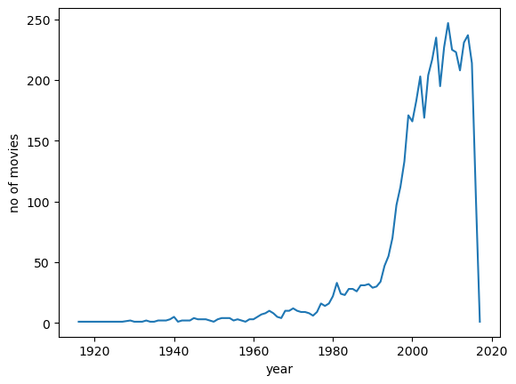

```python
g=sns.lineplot(x,y)
g.set(xlabel ="year", ylabel = "no of movies")
```

#### Top 10 thể loại phim thường xem nhất

```python
genres_value_counts = df_eda['genres'].str.split(',', expand=True).stack().value_counts()
```

```python
genres_value_counts.head(10)
```

```
Drama                   371
Comedy                  282
Drama Romance           164
Comedy Romance          144
Comedy Drama            142
Comedy Drama Romance    109
Horror Thriller          88
Documentary              66
Horror                   64
Drama Thriller           62
dtype: int64
```

```python
y=genres_value_counts[:10]
```

```python
x=genres_value_counts.index[:10]
```

```
<BarContainer object of 10 artists>
```

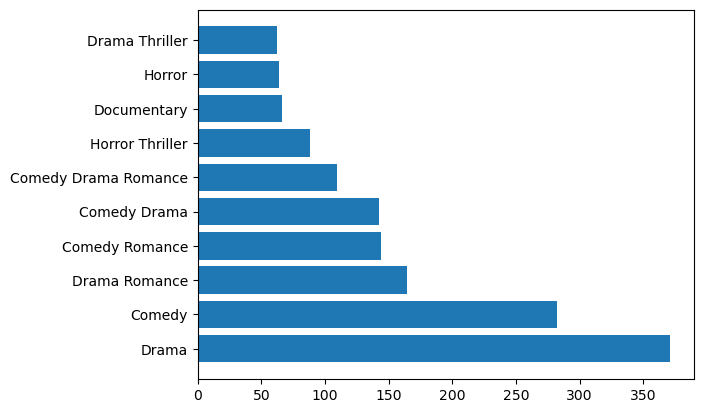

```python
plt.barh(x,y)
```

```python
 df_eda.info()
```

```
<class 'pandas.core.frame.DataFrame'>
Int64Index: 4805 entries, 0 to 4808
Data columns (total 11 columns):
 #   Column                Non-Null Count  Dtype
---  ------                --------------  -----
 0   budget                4805 non-null   int64
 1   popularity            4805 non-null   float64
 2   production_companies  4805 non-null   object
 3   release_date          4805 non-null   object
 4   revenue               4805 non-null   int64
 5   title                 4805 non-null   object
 6   genres                4805 non-null   object
 7   cast                  4805 non-null   object
 8   crew                  4805 non-null   object
 9   year                  4805 non-null   int64
 10  release_month         4805 non-null   int64
dtypes: float64(1), int64(4), object(6)
memory usage: 579.5+ KB
```

```python
crew_value_counts = df_eda['crew'].value_counts()
x = crew_value_counts[1:10]
y = crew_value_counts.index[1:10]
```

```python
crew_value_counts.head(10)
```

```
                    29
StevenSpielberg     26
WoodyAllen          21
MartinScorsese      20
ClintEastwood       20
SpikeLee            16
RidleyScott         16
RennyHarlin         15
StevenSoderbergh    15
TimBurton           14
Name: crew, dtype: int64
```

```
<BarContainer object of 9 artists>
```

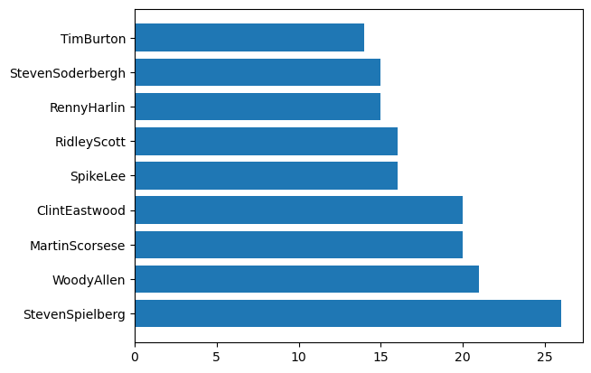

```python
plt.barh(y,x)
```

#### Top 10 nhân viên có ngân sách cao

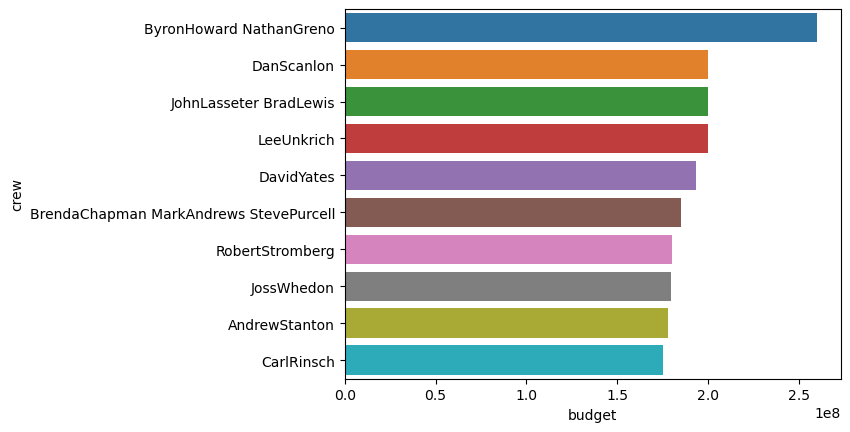

```python
avg_budget_crew=df_eda.groupby("crew")["budget"].mean()
avg_budget_crew=avg_budget_crew.nlargest(10)

sns.barplot(x=avg_budget_crew, y=avg_budget_crew.index)
```

# RECOMMENDATION ENGINED

## Demographic Filtering

```python
df.head()
```

|  | budget | popularity | id | production_companies | release_date | revenue | title | vote_average | vote_count | movie_id | overview | genres | keywords | cast | crew | tags |
| --- | --- | --- | --- | --- | --- | --- | --- | --- | --- | --- | --- | --- | --- | --- | --- | --- |
| 0 | 237000000 | 150.437577 | 19995 | [IngeniousFilmPartners, TwentiethCenturyFoxFil... | 2009-12-10 | 2787965087 | Avatar | 7.2 | 11800 | 19995 | [In, the, 22nd, century,, a, paraplegic, Marin... | [Action, Adventure, Fantasy, ScienceFiction] | [cultureclash, future, spacewar, spacecolony, ... | [SamWorthington, ZoeSaldana] | [JamesCameron] | [In, the, 22nd, century,, a, paraplegic, Marin... |
| 1 | 300000000 | 139.082615 | 285 | [WaltDisneyPictures, JerryBruckheimerFilms] | 2007-05-19 | 961000000 | Pirates of the Caribbean: At World's End | 6.9 | 4500 | 285 | [Captain, Barbossa,, long, believed, to, be, d... | [Adventure, Fantasy, Action] | [ocean, drugabuse, exoticisland, eastindiatrad... | [JohnnyDepp, OrlandoBloom] | [GoreVerbinski] | [Captain, Barbossa,, long, believed, to, be, d... |
| 2 | 245000000 | 107.376788 | 206647 | [ColumbiaPictures, Danjaq] | 2015-10-26 | 880674609 | Spectre | 6.3 | 4466 | 206647 | [A, cryptic, message, from, Bond’s, past, send... | [Action, Adventure, Crime] | [spy, basedonnovel, secretagent, sequel, mi6, ... | [DanielCraig, ChristophWaltz] | [SamMendes] | [A, cryptic, message, from, Bond’s, past, send... |
| 3 | 250000000 | 112.312950 | 49026 | [LegendaryPictures, WarnerBros.] | 2012-07-16 | 1084939099 | The Dark Knight Rises | 7.6 | 9106 | 49026 | [Following, the, death, of, District, Attorney... | [Action, Crime, Drama, Thriller] | [dccomics, crimefighter, terrorist, secretiden... | [ChristianBale, MichaelCaine] | [ChristopherNolan] | [Following, the, death, of, District, Attorney... |
| 4 | 260000000 | 43.926995 | 49529 | [WaltDisneyPictures] | 2012-03-07 | 284139100 | John Carter | 6.1 | 2124 | 49529 | [John, Carter, is, a, war-weary,, former, mili... | [Action, Adventure, ScienceFiction] | [basedonnovel, mars, medallion, spacetravel, p... | [TaylorKitsch, LynnCollins] | [AndrewStanton] | [John, Carter, is, a, war-weary,, former, mili... |

```python
df_Filter=df[["id","title","popularity","vote_average","vote_count"]]
df_Filter.head()
```

|  | id | title | popularity | vote_average | vote_count |
| --- | --- | --- | --- | --- | --- |
| 0 | 19995 | Avatar | 150.437577 | 7.2 | 11800 |
| 1 | 285 | Pirates of the Caribbean: At World's End | 139.082615 | 6.9 | 4500 |
| 2 | 206647 | Spectre | 107.376788 | 6.3 | 4466 |
| 3 | 49026 | The Dark Knight Rises | 112.312950 | 7.6 | 9106 |
| 4 | 49529 | John Carter | 43.926995 | 6.1 | 2124 |

```python
df_Filter.info()
```

```
<class 'pandas.core.frame.DataFrame'>
Int64Index: 4805 entries, 0 to 4808
Data columns (total 5 columns):
 #   Column        Non-Null Count  Dtype
---  ------        --------------  -----
 0   id            4805 non-null   int64
 1   title         4805 non-null   object
 2   popularity    4805 non-null   float64
 3   vote_average  4805 non-null   float64
 4   vote_count    4805 non-null   int64
dtypes: float64(2), int64(2), object(1)
memory usage: 354.3+ KB
```

```python
C= df_Filter['vote_average'].mean()
C
```

```
6.094526534859516
```

```python
m= df_Filter['vote_count'].quantile(0.9)
m
```

```
1846.600000000004
```

```python
q_movies = df_Filter.copy().loc[df_Filter['vote_count'] >= m]
q_movies.shape
```

```
(481, 5)
```

```python
def weighted_rating(x, m=m, C=C):
    v = x['vote_count']
    R = x['vote_average']
    return (v/(v+m) * R) + (m/(m+v) * C)
```

```python
q_movies['score'] = q_movies.apply(weighted_rating, axis=1)
```

```python
q_movies = q_movies.sort_values('score', ascending=False)
q_movies[['title', 'vote_count', 'vote_average', 'score']].head(10)
```

|  | title | vote_count | vote_average | score |
| --- | --- | --- | --- | --- |
| 1887 | The Shawshank Redemption | 8205 | 8.5 | 8.058086 |
| 662 | Fight Club | 9413 | 8.3 | 7.938297 |
| 65 | The Dark Knight | 12002 | 8.2 | 7.919252 |
| 3237 | Pulp Fiction | 8428 | 8.3 | 7.903622 |
| 96 | Inception | 13752 | 8.1 | 7.862587 |
| 3342 | The Godfather | 5893 | 8.4 | 7.849934 |
| 95 | Interstellar | 10867 | 8.1 | 7.808713 |
| 809 | Forrest Gump | 7927 | 8.2 | 7.802197 |
| 329 | The Lord of the Rings: The Return of the King | 8064 | 8.1 | 7.726329 |
| 1996 | The Empire Strikes Back | 5879 | 8.2 | 7.696742 |

```python
import matplotlib.pyplot as plt
from matplotlib import pyplot as plt
```

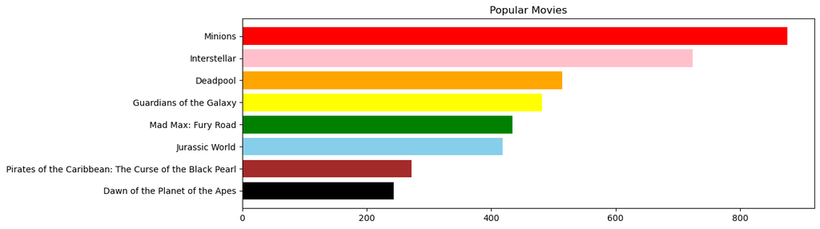

```python
pop= df_Filter.sort_values('popularity', ascending=False)
plt.figure(figsize=(12,4))
plt.barh(pop['title'].head(8),pop['popularity'].head(8), align='center',
       color=['red','pink','orange','yellow','green',"skyblue","brown","black"])
plt.gca().invert_yaxis()
plt.title("Popular Movies")
plt.show()
```

### CONTANT BASED RECOMMENDATION

```python
df2=df
df2['overview'].head(5)
```

```
0    [In, the, 22nd, century,, a, paraplegic, Marin...
1    [Captain, Barbossa,, long, believed, to, be, d...
2    [A, cryptic, message, from, Bond’s, past, send...
3    [Following, the, death, of, District, Attorney...
4    [John, Carter, is, a, war-weary,, former, mili...
Name: overview, dtype: object
```

```python
df2['overview'] = df2['overview'].apply(lambda x: " ".join(x))
```

```python
df2['overview'].head(5)
```

```
0    In the 22nd century, a paraplegic Marine is di...
1    Captain Barbossa, long believed to be dead, ha...
2    A cryptic message from Bond’s past sends him o...
3    Following the death of District Attorney Harve...
4    John Carter is a war-weary, former military ca...
Name: overview, dtype: object
```

```python
from sklearn.feature_extraction.text import TfidfVectorizer
#Xác định Đối tượng Vectorizer TF-IDF. Xóa tất cả các stop_words tiếng Anh
tfidf = TfidfVectorizer(stop_words='english')
#Replace NaN with to empty
df2['overview'] = df2['overview'].fillna('')
#Xây dựng ma trận TF-IDF  bằng cách fit và transform dữ liệu
tfidf_matrix = tfidf.fit_transform(df2['overview'])

tfidf_matrix.shape
```

```
(4805, 20977)
```

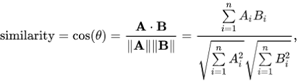

```python
from sklearn.metrics.pairwise import cosine_similarity

# tính toán  cosine similarity matrix
cosine_sim = cosine_similarity(tfidf_matrix, tfidf_matrix)
```

```python
#Xây dựng map đảo ngược các chỉ số và tiêu đề phim
indices = pd.Series(df2.index, index=df2['title']).drop_duplicates()
```

```python
# Function that takes in movie title as input and outputs most similar movies
def get_recommendations(title, cosine_sim=cosine_sim):
    # Lấy chỉ mục của phim phù hợp với tiêu đề
    idx = indices[title]
    # Nhận điểm tương đồng cặp đôi của tất cả các phim với phim đó
    sim_scores = list(enumerate(cosine_sim[idx]))
    # Sắp xếp phim dựa trên điểm giống nhau
    sim_scores = sorted(sim_scores, key=lambda x: x[1], reverse=True)

    # Nhận điểm của 10 bộ phim giống nhau nhất
    sim_scores = sim_scores[1:11]
    # Lấy chỉ số phim
    movie_indices = [i[0] for i in sim_scores]
    recommendations = pd.DataFrame({"Movies": df2['title'].iloc[movie_indices],
                                    "Similarity": [sim[1] for sim in sim_scores]})
    # trả về top 10 phim giống nhau nhất và độ similarity
    return recommendations
```

```python
get_recommendations('The Dark Knight Rises')
```

|  | Movies | Similarity |
| --- | --- | --- |
| 65 | The Dark Knight | 0.301122 |
| 299 | Batman Forever | 0.297608 |
| 428 | Batman Returns | 0.286500 |
| 1362 | Batman | 0.263789 |
| 1363 | Batman | 0.263789 |
| 3861 | Batman: The Dark Knight Returns, Part 2 | 0.185759 |
| 2513 | Slow Burn | 0.167173 |
| 119 | Batman Begins | 0.166433 |
| 9 | Batman v Superman: Dawn of Justice | 0.132417 |
| 1184 | JFK | 0.132400 |

##### Credits, Genres and Keywords Based Recommender

```python
def create_soup(x):
    return ' '.join(x['keywords']) + ' ' + ' '.join(x['cast']) + ' ' + ' '.join(x['crew']) + ' ' + ' '.join(x['genres'])
df2['soup'] = df2.apply(create_soup, axis=1)
```

```python
from sklearn.feature_extraction.text import CountVectorizer

count = CountVectorizer(stop_words='english')
count_matrix = count.fit_transform(df2['soup'])
```

```python
from sklearn.metrics.pairwise import cosine_similarity

cosine_sim2 = cosine_similarity(count_matrix, count_matrix)
```

```python
# Đặt lại chỉ mục của Khung dữ liệu chính và xây dựng ánh xạ ngược như trên
df2 = df2.reset_index()
indices = pd.Series(df2.index, index=df2['title'])
```

```python
get_recommendations('The Godfather', cosine_sim2)
```

|  | Movies | Similarity |
| --- | --- | --- |
| 867 | The Godfather: Part III | 0.342997 |
| 2736 | The Godfather: Part II | 0.342997 |
| 2655 | The Son of No One | 0.297044 |
| 1021 | The Cotton Club | 0.292509 |
| 1212 | The Rainmaker | 0.280056 |
| 3297 | 10th & Wolf | 0.280056 |
| 4640 | Amidst the Devil's Wings | 0.280056 |
| 877 | Black Mass | 0.257248 |
| 1400 | Donnie Brasco | 0.242536 |
| 3972 | Point Blank | 0.230089 |

```python
get_recommendations("The Dark Knight Rises",cosine_sim2)
```

|  | Movies | Similarity |
| --- | --- | --- |
| 65 | The Dark Knight | 0.555937 |
| 119 | Batman Begins | 0.447214 |
| 4640 | Amidst the Devil's Wings | 0.327327 |
| 3336 | Harry Brown | 0.298807 |
| 3825 | Defendor | 0.298807 |
| 4105 | Harsh Times | 0.298807 |
| 3363 | In Too Deep | 0.285714 |
| 210 | Batman & Robin | 0.283473 |
| 1509 | Takers | 0.267261 |
| 1992 | Faster | 0.267261 |

### APRIORI ALGORITHIOM BASED RECOMMENDATION

```python
df3.head()
```

|  | userId | movie_id | rating | timestamp | budget | popularity | id | production_companies | release_date | revenue | title | vote_average | vote_count | overview | genres | keywords | cast | crew | tags |
| --- | --- | --- | --- | --- | --- | --- | --- | --- | --- | --- | --- | --- | --- | --- | --- | --- | --- | --- | --- |
| 0 | 1 | 70 | 3.0 | 964982400 | 30000000 | 70.456012 | 70 | [LakeshoreEntertainment, MalpasoProductions] | 2004-12-15 | 216763646 | Million Dollar Baby | 7.7 | 2439 | [Despondent, over, a, painful, estrangement, f... | [Drama] | [transporter, suicideattempt, strongwoman, box... | [ClintEastwood, HilarySwank] | [ClintEastwood] | [Despondent, over, a, painful, estrangement, f... |
| 1 | 18 | 70 | 3.5 | 1455735732 | 30000000 | 70.456012 | 70 | [LakeshoreEntertainment, MalpasoProductions] | 2004-12-15 | 216763646 | Million Dollar Baby | 7.7 | 2439 | [Despondent, over, a, painful, estrangement, f... | [Drama] | [transporter, suicideattempt, strongwoman, box... | [ClintEastwood, HilarySwank] | [ClintEastwood] | [Despondent, over, a, painful, estrangement, f... |
| 2 | 19 | 70 | 2.0 | 965704974 | 30000000 | 70.456012 | 70 | [LakeshoreEntertainment, MalpasoProductions] | 2004-12-15 | 216763646 | Million Dollar Baby | 7.7 | 2439 | [Despondent, over, a, painful, estrangement, f... | [Drama] | [transporter, suicideattempt, strongwoman, box... | [ClintEastwood, HilarySwank] | [ClintEastwood] | [Despondent, over, a, painful, estrangement, f... |
| 3 | 34 | 70 | 3.5 | 1162048002 | 30000000 | 70.456012 | 70 | [LakeshoreEntertainment, MalpasoProductions] | 2004-12-15 | 216763646 | Million Dollar Baby | 7.7 | 2439 | [Despondent, over, a, painful, estrangement, f... | [Drama] | [transporter, suicideattempt, strongwoman, box... | [ClintEastwood, HilarySwank] | [ClintEastwood] | [Despondent, over, a, painful, estrangement, f... |
| 4 | 45 | 70 | 4.0 | 951170563 | 30000000 | 70.456012 | 70 | [LakeshoreEntertainment, MalpasoProductions] | 2004-12-15 | 216763646 | Million Dollar Baby | 7.7 | 2439 | [Despondent, over, a, painful, estrangement, f... | [Drama] | [transporter, suicideattempt, strongwoman, box... | [ClintEastwood, HilarySwank] | [ClintEastwood] | [Despondent, over, a, painful, estrangement, f... |

```python
df_final=df3[["userId", "movie_id", "title", "rating"]]
df_final.head()
```

|  | userId | movie_id | title | rating |
| --- | --- | --- | --- | --- |
| 0 | 1 | 70 | Million Dollar Baby | 3.0 |
| 1 | 18 | 70 | Million Dollar Baby | 3.5 |
| 2 | 19 | 70 | Million Dollar Baby | 2.0 |
| 3 | 34 | 70 | Million Dollar Baby | 3.5 |
| 4 | 45 | 70 | Million Dollar Baby | 4.0 |

```python
df_final ['rating'] = np.ceil(df_final['rating'])
df_final.rating.unique()
```

```
array([3., 4., 2., 5., 1.])
```

```python
movieId_dict = df_final.drop_duplicates('title')[['movie_id', 'title']].set_index('movie_id').to_dict()['title']
list(movieId_dict.items())[:5]
```

```
[(70, 'Million Dollar Baby'),
 (157, 'Star Trek III: The Search for Spock'),
 (163, "Ocean's Twelve"),
 (223, 'Rebecca'),
 (231, 'Syriana')]
```

```python
movieId_dict.get(70)
```

```
'Million Dollar Baby'
```

```python
df_final.isnull().sum()
```

```
userId      0
movie_id    0
title       0
rating      0
dtype: int64
```

```python
df_final.nunique()
```

```
userId      598
movie_id    824
title       824
rating        5
dtype: int64
```

```python
df_final2=df_final.drop_duplicates(subset=['userId'])
df_final2.info()
```

```
<class 'pandas.core.frame.DataFrame'>
Int64Index: 598 entries, 0 to 16247
Data columns (total 4 columns):
 #   Column    Non-Null Count  Dtype
---  ------    --------------  -----
 0   userId    598 non-null    int64
 1   movie_id  598 non-null    int64
 2   title     598 non-null    object
 3   rating    598 non-null    float64
dtypes: float64(1), int64(2), object(1)
memory usage: 23.4+ KB
```

```python
dataRecommendation = df_final.pivot_table(index='userId', columns='movie_id', values='rating').fillna(0)
dataRecommendation.columns = dataRecommendation.columns.map(movieId_dict)
dataRecommendation.head(10)
```

| movie_id userId | Four Rooms | Star Wars | Finding Nemo | Forrest Gump | American Beauty | Dancer in the Dark | The Fifth Element | Metropolis | My Life Without Me | Pirates of the Caribbean: The Curse of the Black Pearl | ... | Contraband | The Smurfs 2 | Chasing Mavericks | This Is 40 | Escape Plan | Stitches | Foodfight! | About Time | The Mortal Instruments: City of Bones | The Lost Medallion: The Adventures of Billy Stone |
| --- | --- | --- | --- | --- | --- | --- | --- | --- | --- | --- | --- | --- | --- | --- | --- | --- | --- | --- | --- | --- | --- |
| 1 | 0.0 | 0.0 | 0.0 | 0.0 | 0.0 | 0.0 | 0.0 | 0.0 | 0.0 | 0.0 | ... | 0.0 | 0.0 | 0.0 | 0.0 | 0.0 | 0.0 | 0.0 | 0.0 | 0.0 | 0.0 |
| 3 | 0.0 | 0.0 | 0.0 | 0.0 | 0.0 | 0.0 | 0.0 | 0.0 | 0.0 | 0.0 | ... | 0.0 | 0.0 | 0.0 | 0.0 | 0.0 | 0.0 | 0.0 | 0.0 | 0.0 | 0.0 |
| 4 | 0.0 | 0.0 | 0.0 | 0.0 | 0.0 | 0.0 | 0.0 | 0.0 | 0.0 | 0.0 | ... | 0.0 | 0.0 | 0.0 | 0.0 | 0.0 | 0.0 | 0.0 | 0.0 | 0.0 | 0.0 |
| 5 | 0.0 | 0.0 | 0.0 | 0.0 | 0.0 | 0.0 | 0.0 | 0.0 | 0.0 | 0.0 | ... | 0.0 | 0.0 | 0.0 | 0.0 | 0.0 | 0.0 | 0.0 | 0.0 | 0.0 | 0.0 |
| 6 | 5.0 | 4.0 | 0.0 | 3.0 | 0.0 | 4.0 | 0.0 | 2.0 | 0.0 | 5.0 | ... | 0.0 | 0.0 | 0.0 | 0.0 | 0.0 | 0.0 | 0.0 | 0.0 | 0.0 | 0.0 |
| 7 | 0.0 | 0.0 | 0.0 | 0.0 | 0.0 | 0.0 | 0.0 | 0.0 | 0.0 | 0.0 | ... | 0.0 | 0.0 | 0.0 | 0.0 | 0.0 | 0.0 | 0.0 | 0.0 | 0.0 | 0.0 |
| 8 | 0.0 | 4.0 | 0.0 | 0.0 | 0.0 | 0.0 | 0.0 | 0.0 | 0.0 | 0.0 | ... | 0.0 | 0.0 | 0.0 | 0.0 | 0.0 | 0.0 | 0.0 | 0.0 | 0.0 | 0.0 |
| 9 | 0.0 | 0.0 | 0.0 | 0.0 | 0.0 | 0.0 | 0.0 | 0.0 | 0.0 | 0.0 | ... | 0.0 | 0.0 | 0.0 | 0.0 | 0.0 | 0.0 | 0.0 | 0.0 | 0.0 | 0.0 |
| 10 | 0.0 | 0.0 | 0.0 | 0.0 | 0.0 | 0.0 | 0.0 | 0.0 | 0.0 | 0.0 | ... | 0.0 | 0.0 | 0.0 | 0.0 | 0.0 | 0.0 | 0.0 | 0.0 | 0.0 | 0.0 |
| 11 | 0.0 | 0.0 | 0.0 | 0.0 | 0.0 | 0.0 | 0.0 | 0.0 | 0.0 | 0.0 | ... | 0.0 | 0.0 | 0.0 | 0.0 | 0.0 | 0.0 | 0.0 | 0.0 | 0.0 | 0.0 |

10 rows × 824 columns

```python
def encode_units(k):
    if k <= 0:
        return 0
    if k >= 1:
        return 1
sets = dataRecommendation.applymap(encode_units)
sets.head(10)
```

| movie_id userId | Four Rooms | Star Wars | Finding Nemo | Forrest Gump | American Beauty | Dancer in the Dark | The Fifth Element | Metropolis | My Life Without Me | Pirates of the Caribbean: The Curse of the Black Pearl | ... | Contraband | The Smurfs 2 | Chasing Mavericks | This Is 40 | Escape Plan | Stitches | Foodfight! | About Time | The Mortal Instruments: City of Bones | The Lost Medallion: The Adventures of Billy Stone |
| --- | --- | --- | --- | --- | --- | --- | --- | --- | --- | --- | --- | --- | --- | --- | --- | --- | --- | --- | --- | --- | --- |
| 1 | 0 | 0 | 0 | 0 | 0 | 0 | 0 | 0 | 0 | 0 | ... | 0 | 0 | 0 | 0 | 0 | 0 | 0 | 0 | 0 | 0 |
| 3 | 0 | 0 | 0 | 0 | 0 | 0 | 0 | 0 | 0 | 0 | ... | 0 | 0 | 0 | 0 | 0 | 0 | 0 | 0 | 0 | 0 |
| 4 | 0 | 0 | 0 | 0 | 0 | 0 | 0 | 0 | 0 | 0 | ... | 0 | 0 | 0 | 0 | 0 | 0 | 0 | 0 | 0 | 0 |
| 5 | 0 | 0 | 0 | 0 | 0 | 0 | 0 | 0 | 0 | 0 | ... | 0 | 0 | 0 | 0 | 0 | 0 | 0 | 0 | 0 | 0 |
| 6 | 1 | 1 | 0 | 1 | 0 | 1 | 0 | 1 | 0 | 1 | ... | 0 | 0 | 0 | 0 | 0 | 0 | 0 | 0 | 0 | 0 |
| 7 | 0 | 0 | 0 | 0 | 0 | 0 | 0 | 0 | 0 | 0 | ... | 0 | 0 | 0 | 0 | 0 | 0 | 0 | 0 | 0 | 0 |
| 8 | 0 | 1 | 0 | 0 | 0 | 0 | 0 | 0 | 0 | 0 | ... | 0 | 0 | 0 | 0 | 0 | 0 | 0 | 0 | 0 | 0 |
| 9 | 0 | 0 | 0 | 0 | 0 | 0 | 0 | 0 | 0 | 0 | ... | 0 | 0 | 0 | 0 | 0 | 0 | 0 | 0 | 0 | 0 |
| 10 | 0 | 0 | 0 | 0 | 0 | 0 | 0 | 0 | 0 | 0 | ... | 0 | 0 | 0 | 0 | 0 | 0 | 0 | 0 | 0 | 0 |
| 11 | 0 | 0 | 0 | 0 | 0 | 0 | 0 | 0 | 0 | 0 | ... | 0 | 0 | 0 | 0 | 0 | 0 | 0 | 0 | 0 | 0 |

10 rows × 824 columns

```python
from mlxtend.frequent_patterns import apriori
from mlxtend.frequent_patterns import association_rules
import random
```

```python
frequent_itemsets = apriori(sets, min_support=0.15, use_colnames=True)
rules = association_rules(frequent_itemsets, metric="lift", min_threshold=1.75).sort_values('lift', ascending=False)
rules = rules[['antecedents', 'consequents', 'support', 'lift', 'confidence']]
rules.head()
```

|  | antecedents | consequents | support | lift | confidence |
| --- | --- | --- | --- | --- | --- |
| 229 | (To Kill a Mockingbird) | (Batman Returns, Silent Hill) | 0.168896 | 3.257362 | 0.691781 |
| 224 | (Batman Returns, Silent Hill) | (To Kill a Mockingbird) | 0.168896 | 3.257362 | 0.795276 |
| 112 | (Lost in Translation) | (Rain Man, The Conversation) | 0.163880 | 3.145341 | 0.715328 |
| 109 | (Rain Man, The Conversation) | (Lost in Translation) | 0.163880 | 3.145341 | 0.720588 |
| 215 | (Reservoir Dogs) | (Batman Returns, Monsoon Wedding) | 0.157191 | 3.049696 | 0.652778 |

```python
i = random.randint(0, rules.shape[0])
print('Antecedents:', rules.iloc[i].antecedents)
print('Consequents:', rules.iloc[i].consequents)
print(f'Lift: {rules.iloc[i].lift.round(3)} & Confidence: {rules.iloc[i].confidence.round(3)} & Support: {rules.iloc[i].support.round(3)}')
```

```
Antecedents: frozenset({'Monsoon Wedding'})
Consequents: frozenset({'Silent Hill'})
Lift: 1.785 & Confidence: 0.546 & Support: 0.217
```

### COLLABRETIVE FILTRING (CF)

```python
from sklearn.neighbors import NearestNeighbors
```

```python
knn = NearestNeighbors(n_neighbors=11, metric='cosine', algorithm='brute', n_jobs=-1)
knn.fit(dataRecommendation.values.T)
```

```
NearestNeighbors(algorithm='brute', metric='cosine', n_jobs=-1, n_neighbors=11)
```

```python
from fuzzywuzzy import process
```

```python
def recommender(movie_name, num_of_recommendations):
    movie_name= process.extractOne(movie_name, df_final['title'])[0]
    print('selected movie is: ',movie_name)
    a = dataRecommendation.columns.to_frame().reset_index(drop=True).to_dict()['movie_id']
    recommendation_result = list(knn.kneighbors([dataRecommendation[movie_name].values], num_of_recommendations + 1))
    recommendation_result = pd.DataFrame(np.vstack((recommendation_result[1], recommendation_result[0])),
                                         index=['id', 'Cosine_Similarity (degree)']).T
    recommendation_result = recommendation_result.drop([0]).reset_index(drop=True)
    recommendation_result.id = recommendation_result.id.map(a)
    return recommendation_result
```

```python
recommender('Forrest Gump', 10)
```

```
selected movie is:  Forrest Gump
```

|  | id | Cosine_Similarity (degree) |
| --- | --- | --- |
| 0 | The Lost Boys | 0.555556 |
| 1 | Licence to Kill | 0.572207 |
| 2 | Riding Giants | 0.595774 |
| 3 | Some Like It Hot | 0.660550 |
| 4 | King Kong | 0.666667 |
| 5 | Volver | 0.666667 |
| 6 | Irreversible | 0.666667 |
| 7 | High Fidelity | 0.666667 |
| 8 | One Flew Over the Cuckoo's Nest | 0.666667 |
| 9 | Bruce Almighty | 0.666667 |

```python
recommender('batman return', 5)
```

```
selected movie is:  Batman Returns
```

|  | id | Cosine_Similarity (degree) |
| --- | --- | --- |
| 0 | Silent Hill | 0.282414 |
| 1 | To Kill a Mockingbird | 0.289445 |
| 2 | Reservoir Dogs | 0.342712 |
| 3 | Monsoon Wedding | 0.386374 |
| 4 | Wag the Dog | 0.438198 |